# Differential gene expression analysis with EdgeR

J. Ignacio Lucas Lledó

# Reading the data

The data for this analysis was created in folder 2019-03-29.

```r
args <- commandArgs(trailingOnly = TRUE)
if (length(args) == 0) {
   stop("At least one argument must be supplied: input file.", call.=FALSE)
} else if (length(args) == 1) {
   args[2] <- "."
}

input_file_name <- args[1]
output_dir <- args[2]
counts <- read.table(input_file_name, row.names=1, header=TRUE)
```

Three factors: population, diapause or hatching condition, and selective regime. I prefer the immediate hatching (instead of forced diapause) and the regular or periodic selective regime as the reference levels of the corresponding factors.

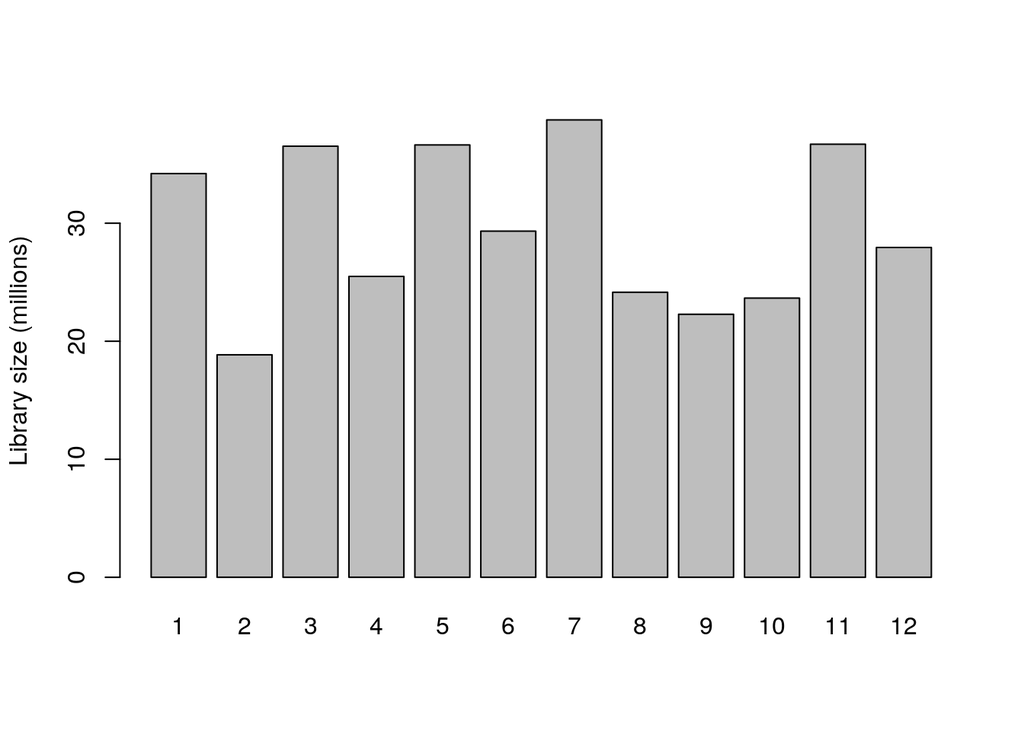

```r
population  <- factor(c("1","1","2","2","1","1","3","3","2","2","3","3"))
diapause <- factor(rep(c("hatch","diapause"), 6))
diapause <- relevel(diapause, "hatch")
regime <- factor(c("random","random","random","random","regular","regular",
                 "random","random","regular","regular","regular","regular"))
regime <- relevel(regime, "regular")

y <- DGEList(counts=counts, group=regime)
y <- calcNormFactors(y, method="TMM")

barplot(y$samples$lib.size*1e-6, names=1:12, ylab="Library size (millions)")
```

It looks like the populations undergoing diapause systematically produced smaller libraries. It may be the effect of a smaller amount of eggs available. Population 5 is the exception.

# Filtering

The recommended filtering consists on removing genes that have such a low expression level that do not have at least 5-10 counts on as many samples as groups there are. The rationale is that those genes cannot have enough reads in at least one sample of each group. However, instead of filtering on the raw counts, the edgeR manual suggests to translate whatever minimum number of reads per library in terms of counts per million. The reason is that the filtering should take into account differences in library sizes between samples. It probably makes sense, because otherwise, I would be applying an effectively higher (harsher) minimum threshold to the gene expression level in samples with smaller libraries. That would probably bias results, since we would be enriching the dataset in genes more highly expressed in some samples than in others.

Say that library sizes range between 250000 and 2000000. Then, applying a minimum expression level of 20 counts per million is the only way to make sure that even the small libraries are required to contain at least 5 counts, while at the same time setting the cutoff at the same biologically relevant level. In any case, as long as the minimum expression level is not enforced in all samples, the dataset retained will contain genes that do not reach the minimum in some samples. Since counts per million are (expectedly and actually) similarly distributed among samples, it should not be the case that any sample is enriched in low-expression genes.

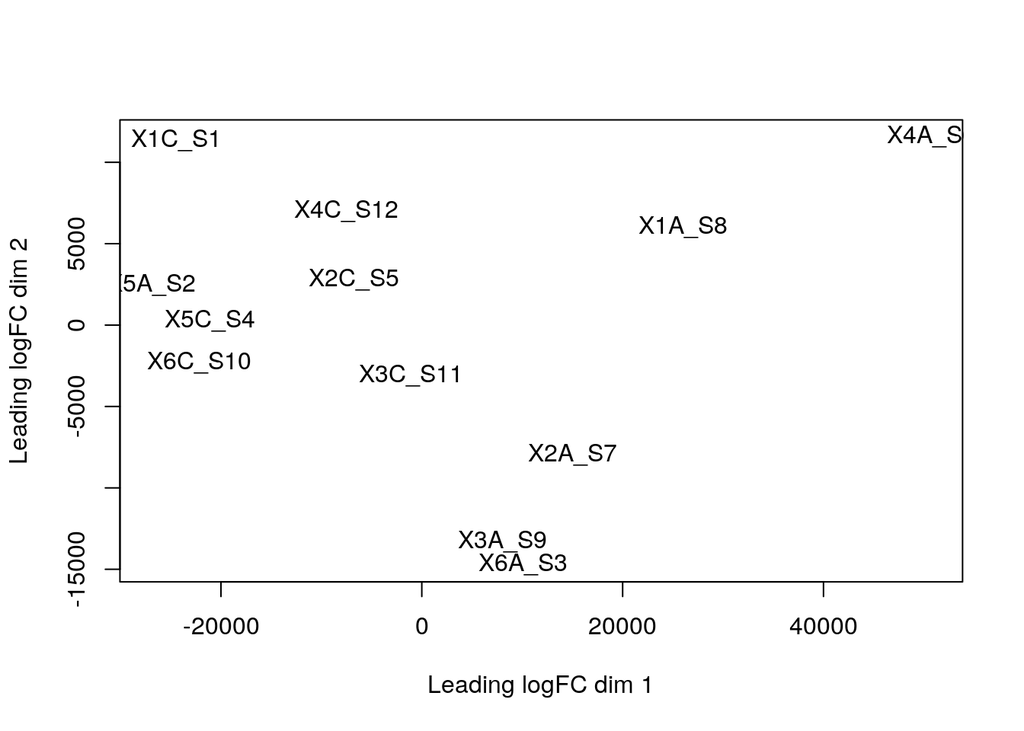

```r
threshold <- 5.0 / (min(y$samples$lib.size) / 1000000)
keep <- rowSums(cpm(y) > threshold) >= 4
y <- y[keep, ,keep.lib.sizes=FALSE]

plotMDS(y$counts)
```

The magnitude of variation along the axes seems very high in comparison with the examples available in the EdgeR manual, suggesting wild gene expression differences. With the exception of sample X5A_S2, dimension 1 separates samples undergoing forced diapause (named with a “C”, mostly on the left half of the plot) from those hatching right away (named with an “A”, mostly on the right). The second dimension is also meaningful, since it almost separates populations 1, 2, and 4, which underwent random regime, from 3, 5 and 6 (regular regime). Sample X2A_S7 is the main exception.

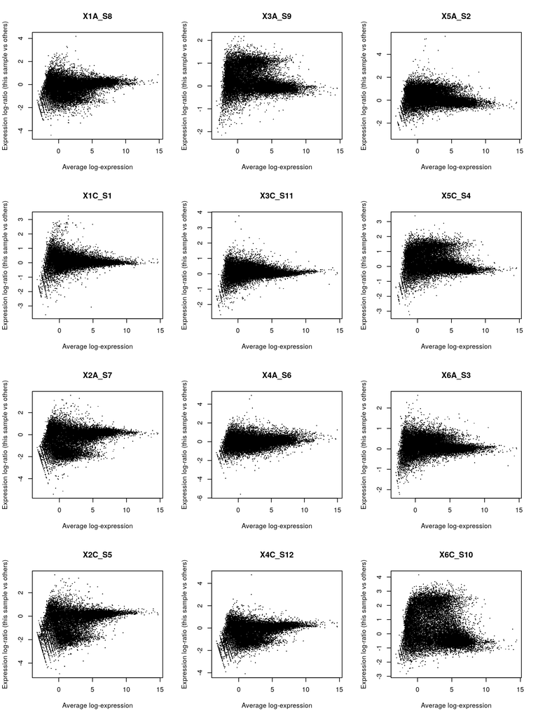

```r
layout(mat=matrix(c(1,2,3,4,5,6,7,8,9,10,11,12), nrow=4, ncol=3), width=c(1,1,1), height=c(1,1,1,1))
for (i in 1:12) {
   plotMD(cpm(y, log=TRUE), column=i)
}
```

```r
layout(mat=matrix(c(1), ncol=1, nrow=1))
```

A lot of genes seem to be differentially expressed.

# Estimating the Biological Coefficient of Variation

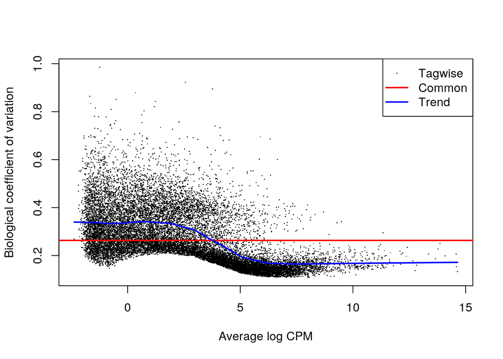

```r
design1 <- model.matrix(~regime + diapause + regime:population)
design2 <- model.matrix(~regime + diapause + regime:population + regime:diapause)

y1 <- estimateDisp(y, design1)
y2 <- estimateDisp(y, design2)

plotBCV(y1)
```

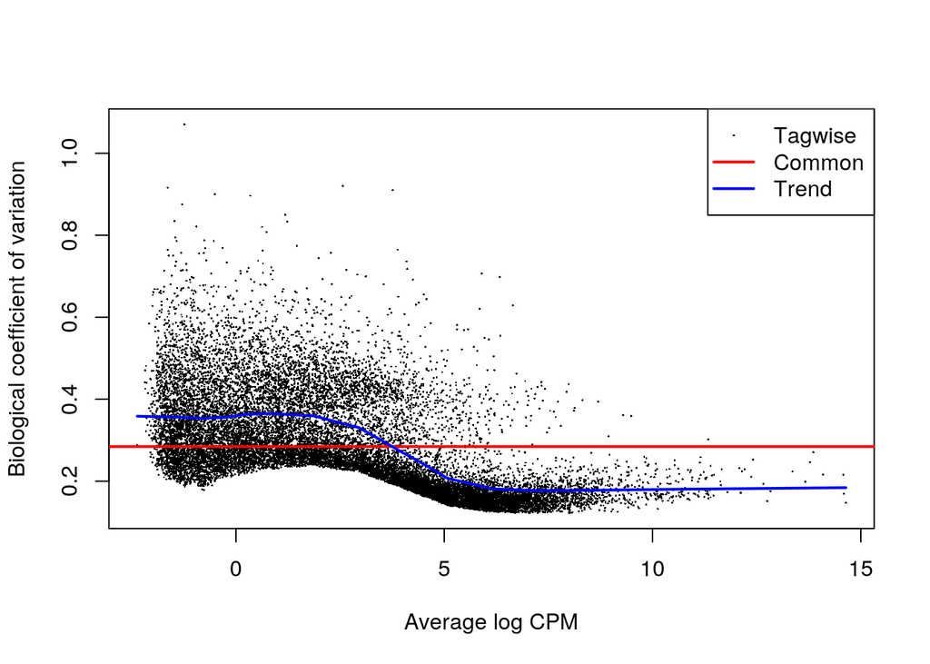

```r
plotBCV(y2)
```

# Fitting the models

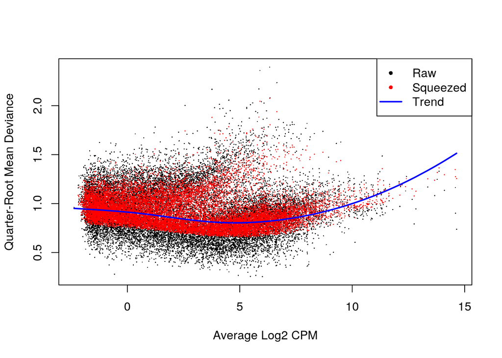

```r
fit1 <- glmQLFit(y1, design1)
fit2 <- glmQLFit(y2, design2)

plotQLDisp(fit1)
```

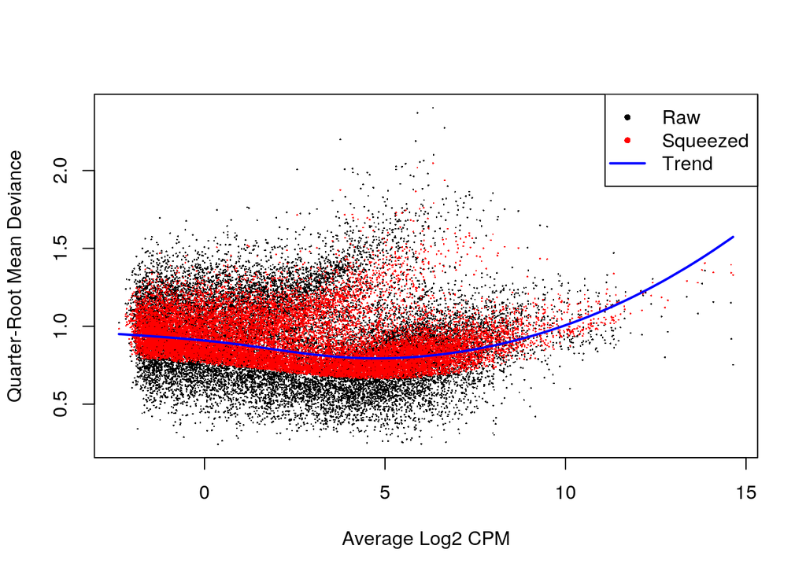

```r
plotQLDisp(fit2)
```

# Contrasts

## Is the interaction term between selective regime and hatching condition necessary?

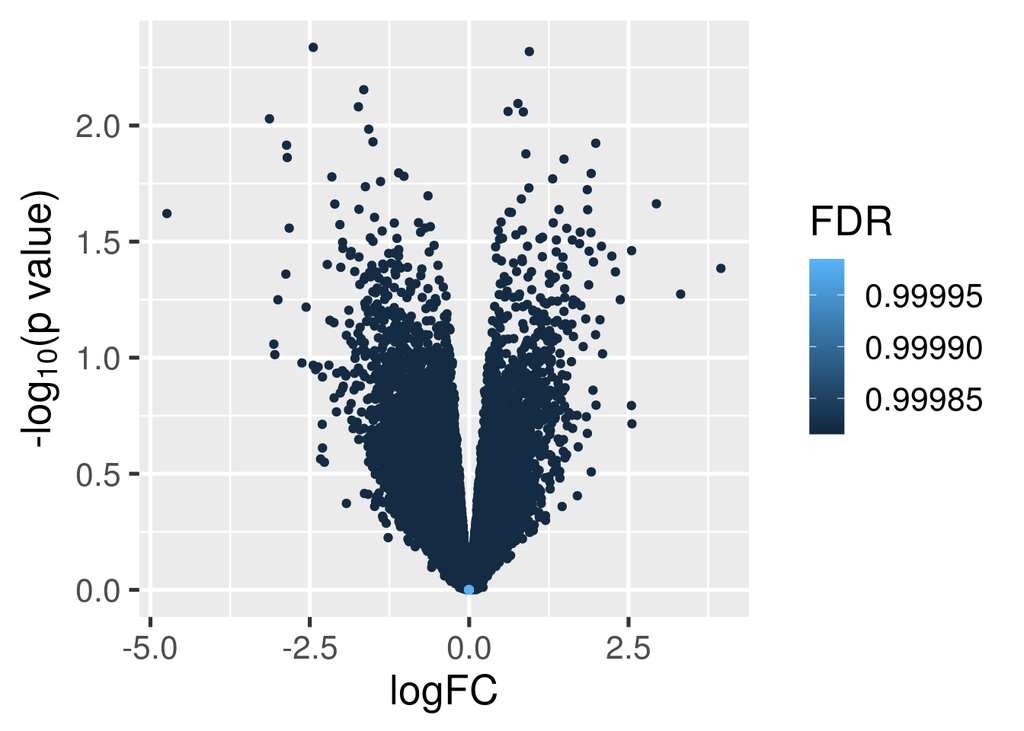

```r
qlf_2 <- glmQLFTest(fit2, coef=8)
genes_with_interaction_term <- topTags(qlf_2, n=dim(y)[1])$table
genes_with_interaction_term$logPValue <- -log10(genes_with_interaction_term$PValue)
ggplot(data=genes_with_interaction_term, mapping=aes(x=logFC, y=logPValue, color=FDR)) +
   geom_point() + theme_grey(base_size=20) + ylab(expression(paste("-log"[10], plain("(p value)"))))
```

```r
NumGenes <- sum(genes_with_interaction_term$FDR <= 0.10)

if (NumGenes > 2) {
   fit <- fit2
} else {
   fit <- fit1
}
```

That is, if there were more than two genes with a significant interaction between the selective regime and the hatching condition (at FDR = 0.1), then I would keep the more complex model, including that interaction. Otherwise (which is actually the case), I keep working with the simpler model with no interaction. Note that in both models coefficients 2 and 3 are the random regime and the forced diapause effects.